# Homework3

```r
library(tidymodels)
library(tidyverse)
library(corrplot)
library(discrim)
library(poissonreg)
library(corrr)
library(klaR)
titanic <- read.csv("titanic.csv")
titanic$survived <- factor(titanic$survived, levels = c("Yes", "No"))
titanic$pclass <- factor(titanic$pclass)
head(titanic)
```

```
##   passenger_id survived pclass
## 1            1       No      3
## 2            2      Yes      1
## 3            3      Yes      3
## 4            4      Yes      1
## 5            5       No      3
## 6            6       No      3
##                                                  name    sex age sib_sp parch
## 1                             Braund, Mr. Owen Harris   male  22      1     0
## 2 Cumings, Mrs. John Bradley (Florence Briggs Thayer) female  38      1     0
## 3                              Heikkinen, Miss. Laina female  26      0     0
## 4        Futrelle, Mrs. Jacques Heath (Lily May Peel) female  35      1     0
## 5                            Allen, Mr. William Henry   male  35      0     0
## 6                                    Moran, Mr. James   male  NA      0     0
##             ticket    fare cabin embarked
## 1        A/5 21171  7.2500  <NA>        S
## 2         PC 17599 71.2833   C85        C
## 3 STON/O2. 3101282  7.9250  <NA>        S
## 4           113803 53.1000  C123        S
## 5           373450  8.0500  <NA>        S
## 6           330877  8.4583  <NA>        Q
```

#### Question1

```r
set.seed(1979)
titanic_split <- initial_split(titanic, prop = 0.8,
                                strata = survived)
titanic_train <- training(titanic_split)
titanic_test <- testing(titanic_split)
c(nrow(titanic_train),nrow(titanic_test))
```

```
## [1] 712 179
```

The training data sets have 712 observation and testing data sets have 179 observation. They both have the appropriate number of observation

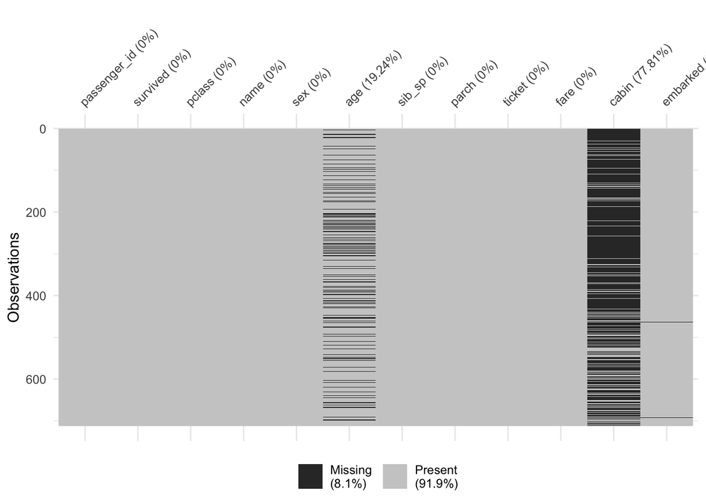

```r
library(naniar)
vis_miss(titanic_train)
```

We have 77.81% missing value in cabin and 19.24% in age.

Why is it a good idea to use stratified sampling for this data? + Stratified sampling can make a representative amount of each level (No/Yes) of variable (survived) is included in the training and testing data set.

#### Question2

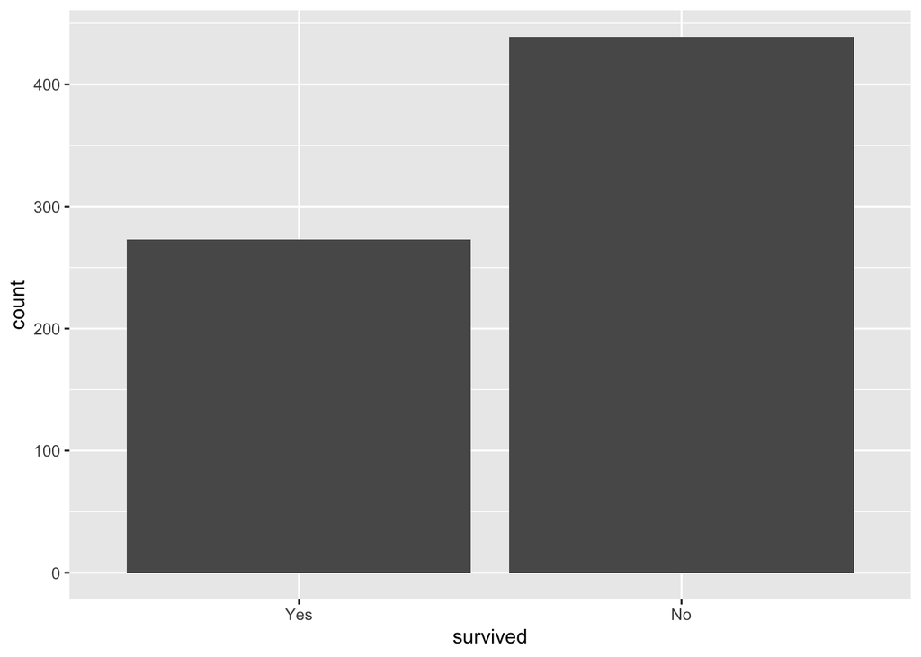

```r
titanic_train %>%
  ggplot(aes(x = survived)) +
  geom_bar()
```

#### Question3

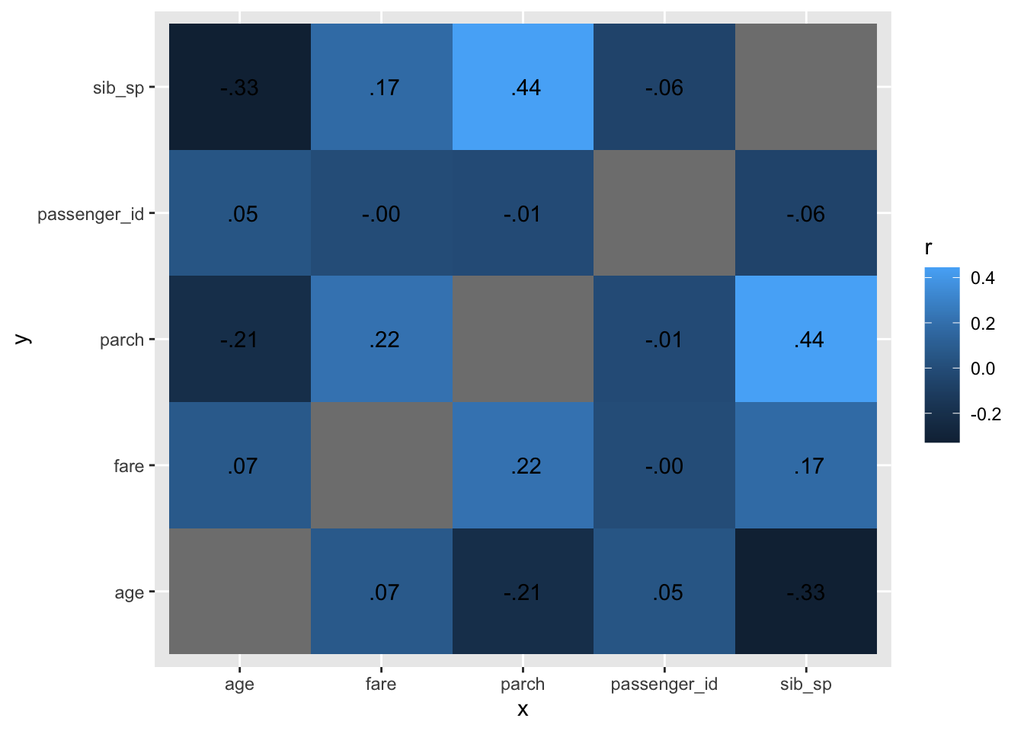

```r
library(corrr)
cor_titanic <- titanic_train %>%
  select_if(is.numeric) %>%
  correlate()

cor_titanic %>%
  stretch() %>%
  ggplot(aes(x, y, fill = r)) +
  geom_tile() +
  geom_text(aes(label = as.character(fashion(r))))
```

We can also use ggplot and the geom_tile() function to create a heatmap-style correlation plot Parch is positive correlated with sib_sp with correlation 0.44 Parch is positive correlated with fare with correlation 0.22 Sib_sp is negative correlated with age with correlation -0.33 Sib_sp is positive correlated with fare with correlation 0.17 Most of variables are not correlated with each other with correlation close to 0

#### Question4

```r
simple_titanic_recipe <-
  recipe(survived ~ pclass+sex+age+sib_sp+parch+fare,data = titanic_train)%>%
  step_impute_linear(age) %>%
  step_dummy(all_nominal_predictors()) %>%
  step_interact(~ fare:starts_with("sex") + age:fare)
```

#### Question5

```r
log_model <- logistic_reg() %>%
  set_engine("glm")

log_wflow <- workflow() %>%
  add_model(log_model) %>%
  add_recipe(simple_titanic_recipe)

log_fit <- fit(log_wflow, titanic_train)
```

#### Question6

```r
lda_mod <- discrim_linear() %>%
  set_mode("classification") %>%
  set_engine("MASS")

lda_wkflow <- workflow() %>%
  add_model(lda_mod) %>%
  add_recipe(simple_titanic_recipe)

lda_fit <- fit(lda_wkflow, titanic_train)
```

#### Question7

```r
qda_mod <- discrim_quad() %>%
  set_mode("classification") %>%
  set_engine("MASS")

qda_wkflow <- workflow() %>%
  add_model(qda_mod) %>%
  add_recipe(simple_titanic_recipe)

qda_fit <- fit(qda_wkflow, titanic_train)
```

#### Question8

```r
nb_mod <- naive_Bayes() %>%
  set_mode("classification") %>%
  set_engine("klaR") %>%
  set_args(usekernel = FALSE)

nb_wkflow <- workflow() %>%
  add_model(nb_mod) %>%
  add_recipe(simple_titanic_recipe)

nb_fit <- fit(nb_wkflow, titanic_train)
```

#### Question9

```r
predict(log_fit, new_data = titanic_train, type = "prob") %>%
  bind_cols(titanic_train)
```

```
## # A tibble: 712 × 14
##    .pred_Yes .pred_No passenger_id survived pclass name       sex     age sib_sp
##        <dbl>    <dbl>        <int> <fct>    <fct>  <chr>      <chr> <dbl>  <int>
##  1    0.112     0.888            1 No       3      Braund, M… male     22      1
##  2    0.0756    0.924            5 No       3      Allen, Mr… male     35      0
##  3    0.111     0.889            6 No       3      Moran, Mr… male     NA      0
##  4    0.324     0.676            7 No       1      McCarthy,… male     54      0
##  5    0.134     0.866            8 No       3      Palsson, … male      2      3
##  6    0.182     0.818           13 No       3      Saunderco… male     20      0
##  7    0.0495    0.950           14 No       3      Andersson… male     39      1
##  8    0.794     0.206           15 No       3      Vestrom, … fema…    14      0
##  9    0.0774    0.923           17 No       3      Rice, Mas… male      2      4
## 10    0.463     0.537           19 No       3      Vander Pl… fema…    31      1
## # … with 702 more rows, and 5 more variables: parch <int>, ticket <chr>,
## #   fare <dbl>, cabin <chr>, embarked <chr>
```

```r
predict(qda_fit, new_data = titanic_train, type = "prob") %>%
  bind_cols(titanic_train)
```

```
## # A tibble: 712 × 14
##      .pred_Yes .pred_No passenger_id survived pclass name     sex     age sib_sp
##          <dbl>    <dbl>        <int> <fct>    <fct>  <chr>    <chr> <dbl>  <int>
##  1 0.00549        0.995            1 No       3      Braund,… male     22      1
##  2 0.00373        0.996            5 No       3      Allen, … male     35      0
##  3 0.00525        0.995            6 No       3      Moran, … male     NA      0
##  4 0.135          0.865            7 No       1      McCarth… male     54      0
##  5 0.000124       1.00             8 No       3      Palsson… male      2      3
##  6 0.00875        0.991           13 No       3      Saunder… male     20      0
##  7 0.550          0.450           14 No       3      Anderss… male     39      1
##  8 0.503          0.497           15 No       3      Vestrom… fema…    14      0
##  9 0.000000685    1.00            17 No       3      Rice, M… male      2      4
## 10 0.232          0.768           19 No       3      Vander … fema…    31      1
## # … with 702 more rows, and 5 more variables: parch <int>, ticket <chr>,
## #   fare <dbl>, cabin <chr>, embarked <chr>
```

```r
predict(lda_fit, new_data = titanic_train, type = "prob") %>%
  bind_cols(titanic_train)
```

```
## # A tibble: 712 × 14
##    .pred_Yes .pred_No passenger_id survived pclass name       sex     age sib_sp
##        <dbl>    <dbl>        <int> <fct>    <fct>  <chr>      <chr> <dbl>  <int>
##  1    0.0694    0.931            1 No       3      Braund, M… male     22      1
##  2    0.0481    0.952            5 No       3      Allen, Mr… male     35      0
##  3    0.0688    0.931            6 No       3      Moran, Mr… male     NA      0
##  4    0.260     0.740            7 No       1      McCarthy,… male     54      0
##  5    0.0878    0.912            8 No       3      Palsson, … male      2      3
##  6    0.110     0.890           13 No       3      Saunderco… male     20      0
##  7    0.0322    0.968           14 No       3      Andersson… male     39      1
##  8    0.841     0.159           15 No       3      Vestrom, … fema…    14      0
##  9    0.0551    0.945           17 No       3      Rice, Mas… male      2      4
## 10    0.567     0.433           19 No       3      Vander Pl… fema…    31      1
## # … with 702 more rows, and 5 more variables: parch <int>, ticket <chr>,
## #   fare <dbl>, cabin <chr>, embarked <chr>
```

```r
# naive Bayes model
predict(nb_fit, new_data = titanic_train, type = "prob") %>%
  bind_cols(titanic_train)
```

```
## # A tibble: 712 × 14
##     .pred_Yes .pred_No passenger_id survived pclass name      sex     age sib_sp
##         <dbl>    <dbl>        <int> <fct>    <fct>  <chr>     <chr> <dbl>  <int>
##  1 0.0155        0.984            1 No       3      Braund, … male     22      1
##  2 0.0152        0.985            5 No       3      Allen, M… male     35      0
##  3 0.0158        0.984            6 No       3      Moran, M… male     NA      0
##  4 0.573         0.427            7 No       1      McCarthy… male     54      0
##  5 0.000278      1.00             8 No       3      Palsson,… male      2      3
##  6 0.0176        0.982           13 No       3      Saunderc… male     20      0
##  7 0.0960        0.904           14 No       3      Andersso… male     39      1
##  8 0.475         0.525           15 No       3      Vestrom,… fema…    14      0
##  9 0.00000328    1.00            17 No       3      Rice, Ma… male      2      4
## 10 0.383         0.617           19 No       3      Vander P… fema…    31      1
## # … with 702 more rows, and 5 more variables: parch <int>, ticket <chr>,
## #   fare <dbl>, cabin <chr>, embarked <chr>
```

```r
log_reg_acc <- augment(log_fit, new_data = titanic_train) %>%
  accuracy(truth = survived, estimate = .pred_class)
```

```r
lda_acc <- augment(lda_fit, new_data = titanic_train) %>%
  accuracy(truth = survived, estimate = .pred_class)
```

```r
qda_acc <- augment(qda_fit, new_data = titanic_train) %>%
  accuracy(truth = survived, estimate = .pred_class)
qda_acc
```

```
## # A tibble: 1 × 3
##   .metric  .estimator .estimate
##   <chr>    <chr>          <dbl>
## 1 accuracy binary         0.760
```

```r
nb_acc <- augment(nb_fit, new_data = titanic_train) %>%
  accuracy(truth = survived, estimate = .pred_class)
nb_acc
```

```
## # A tibble: 1 × 3
##   .metric  .estimator .estimate
##   <chr>    <chr>          <dbl>
## 1 accuracy binary         0.760
```

```r
accuracies <- c(log_reg_acc$.estimate, lda_acc$.estimate,
                nb_acc$.estimate, qda_acc$.estimate)
models <- c("Logistic Regression", "LDA", "Naive Bayes", "QDA")
results <- tibble(accuracies = accuracies, models = models)
results %>%
  arrange(-accuracies)
```

```
## # A tibble: 4 × 2
##   accuracies models
##        <dbl> <chr>
## 1      0.808 Logistic Regression
## 2      0.799 LDA
## 3      0.760 Naive Bayes
## 4      0.760 QDA
```

Logistic Regression achieved highest accuracy on the training data

#### Question 10

```r
predict(log_fit, new_data = titanic_test, type = "prob")
```

```
## # A tibble: 179 × 2
##    .pred_Yes .pred_No
##        <dbl>    <dbl>
##  1    0.819     0.181
##  2    0.219     0.781
##  3    0.415     0.585
##  4    0.0322    0.968
##  5    0.324     0.676
##  6    0.111     0.889
##  7    0.757     0.243
##  8    0.292     0.708
##  9    0.382     0.618
## 10    0.814     0.186
## # … with 169 more rows
```

```r
multi_metric <- metric_set(accuracy, sensitivity, specificity)

augment(log_fit, new_data = titanic_test) %>%
  multi_metric(truth = survived, estimate = .pred_class)
```

```
## # A tibble: 3 × 3
##   .metric     .estimator .estimate
##   <chr>       <chr>          <dbl>
## 1 accuracy    binary         0.799
## 2 sensitivity binary         0.754
## 3 specificity binary         0.827
```

The accuracy of the model on the testing data is 0.7988827

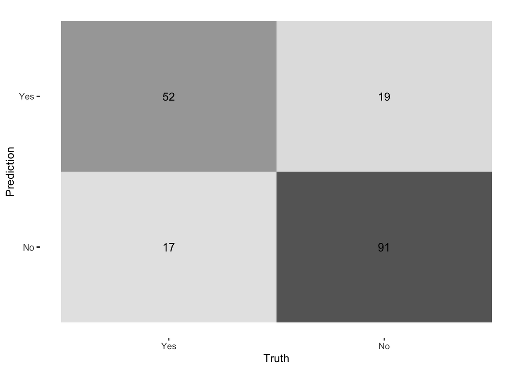

```r
augment(log_fit, new_data = titanic_test) %>%
  conf_mat(truth = survived, estimate = .pred_class) %>%
  autoplot(type = "heatmap")
```

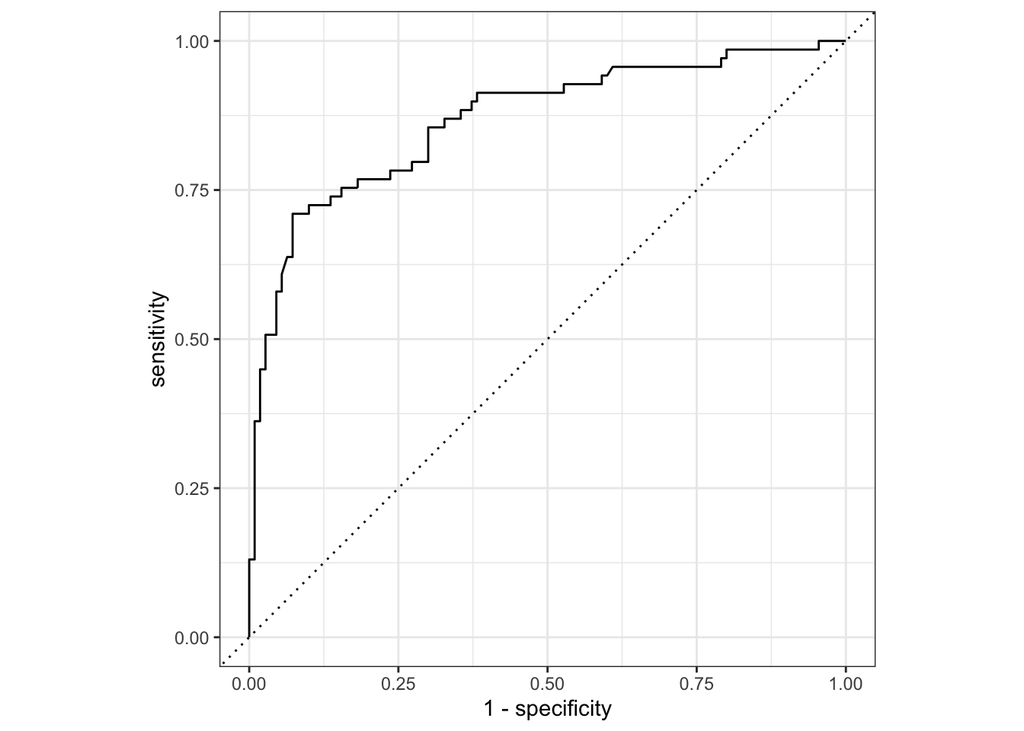

```r
augment(log_fit, new_data = titanic_test) %>%
  roc_curve(survived, .pred_Yes) %>%
  autoplot()
```

```r
augment(log_fit, new_data = titanic_test) %>%
  roc_auc(survived, .pred_Yes)
```

```
## # A tibble: 1 × 3
##   .metric .estimator .estimate
##   <chr>   <chr>          <dbl>
## 1 roc_auc binary         0.867
```

The model preforms well. The accuracy between training and testing is similar and both close to 80.